# Multi-Class Classification Model for [Project Name] Using R version 10

### 2.b) Data visualizations

#### 2.b.i) Univariate plots to better understand each attribute.

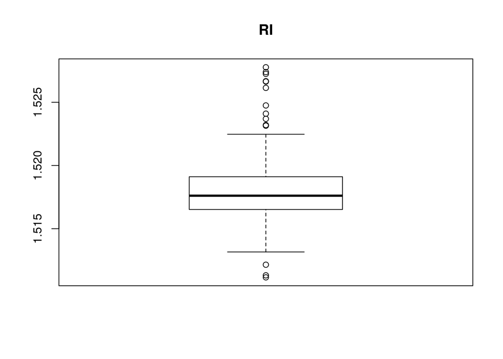

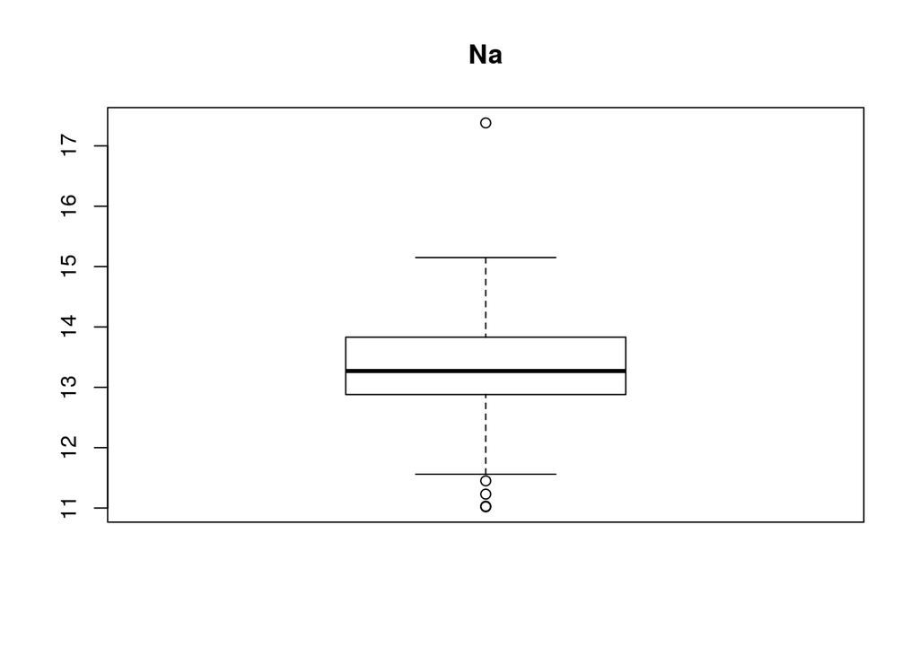

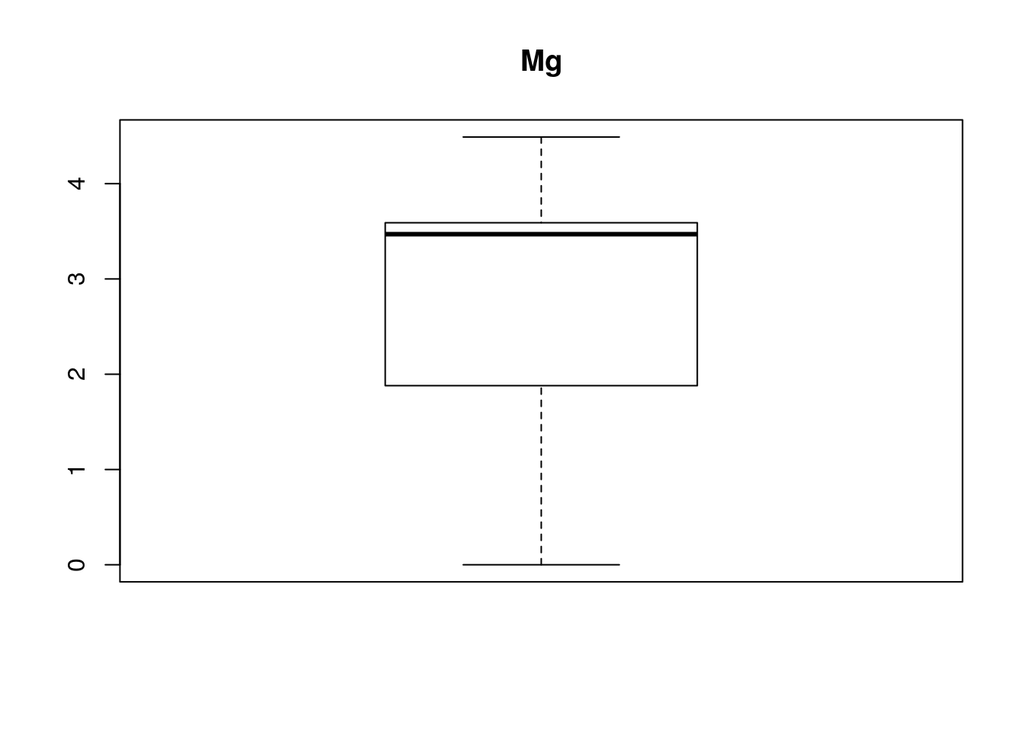

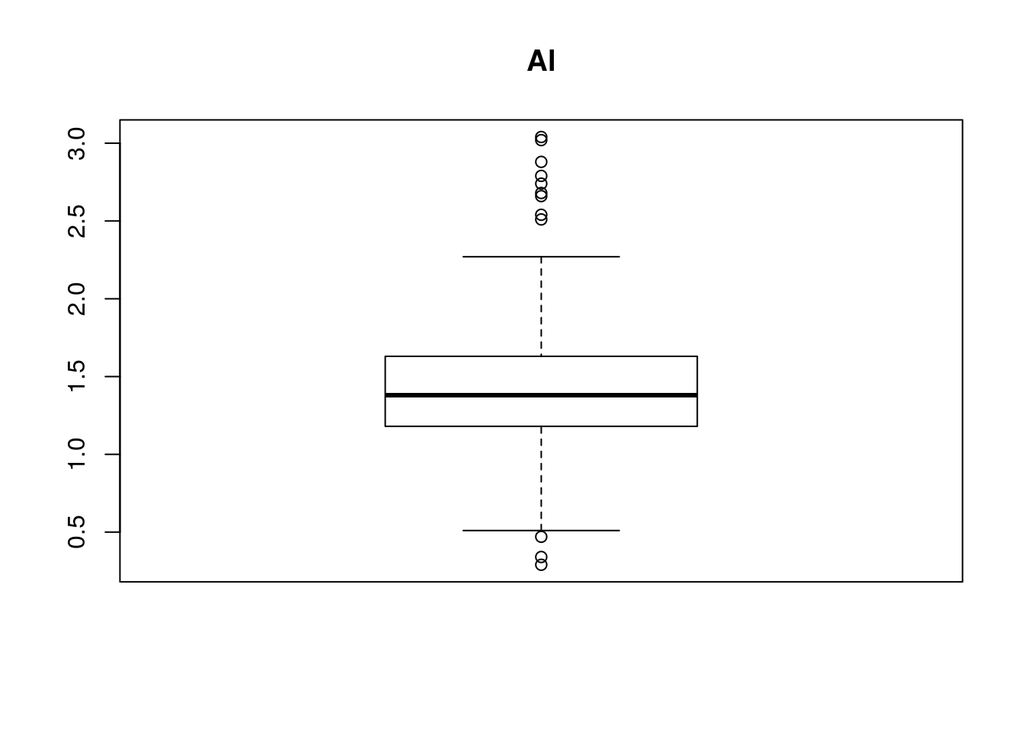

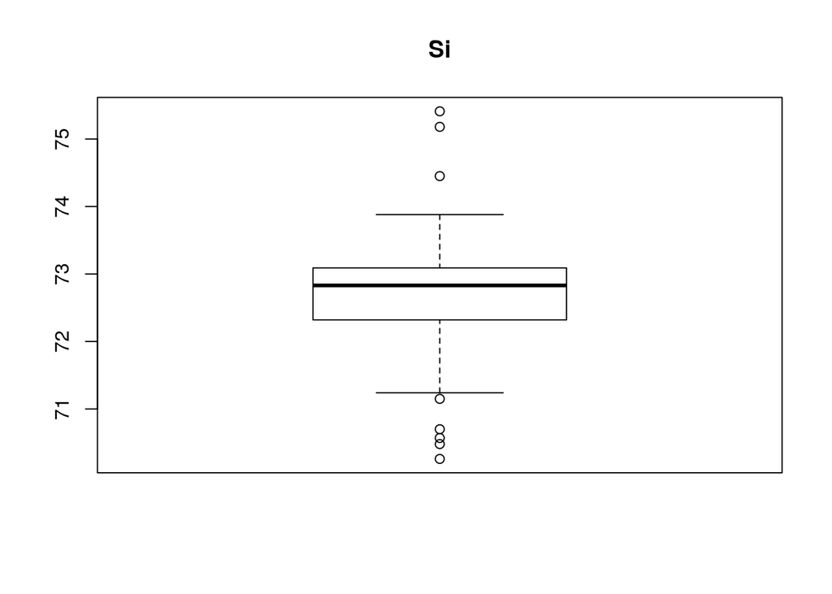

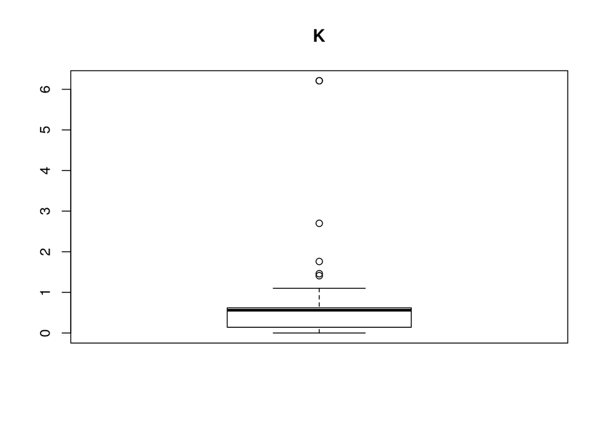

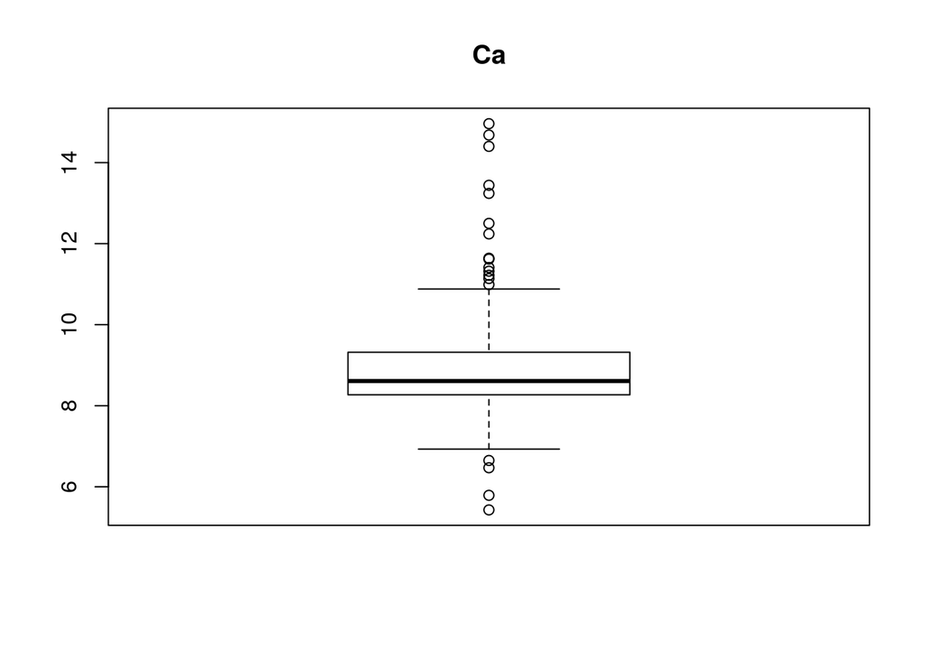

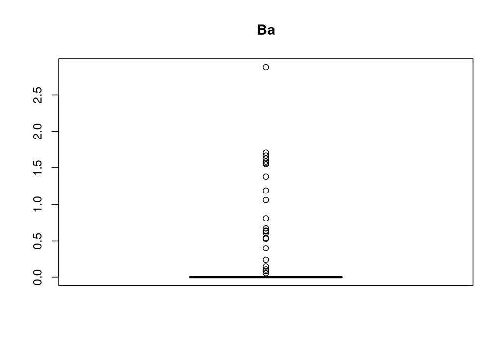

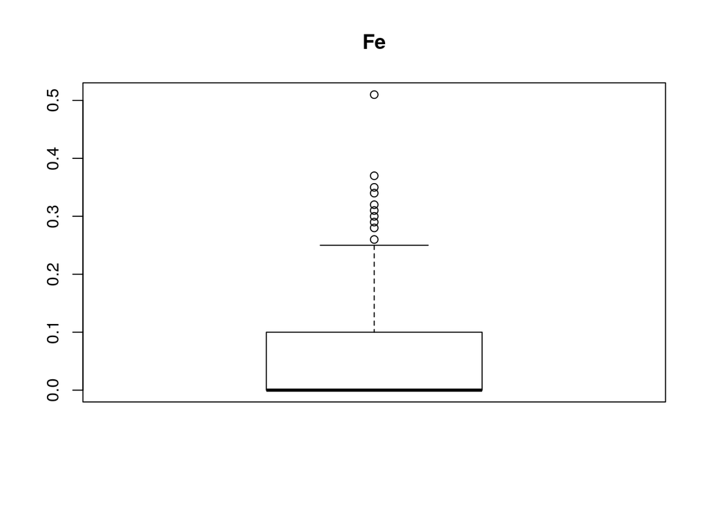

```r
# Boxplots for each attribute
# par(mfrow=c(dispRow,dispCol))
for(i in 1:totAttr) {
    boxplot(x_train[,i], main=names(x_train)[i])
}
```

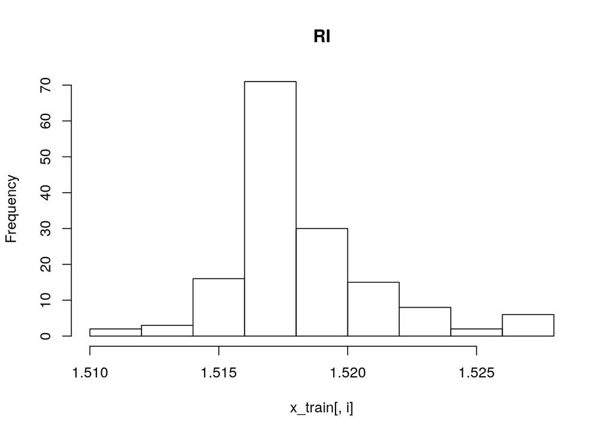

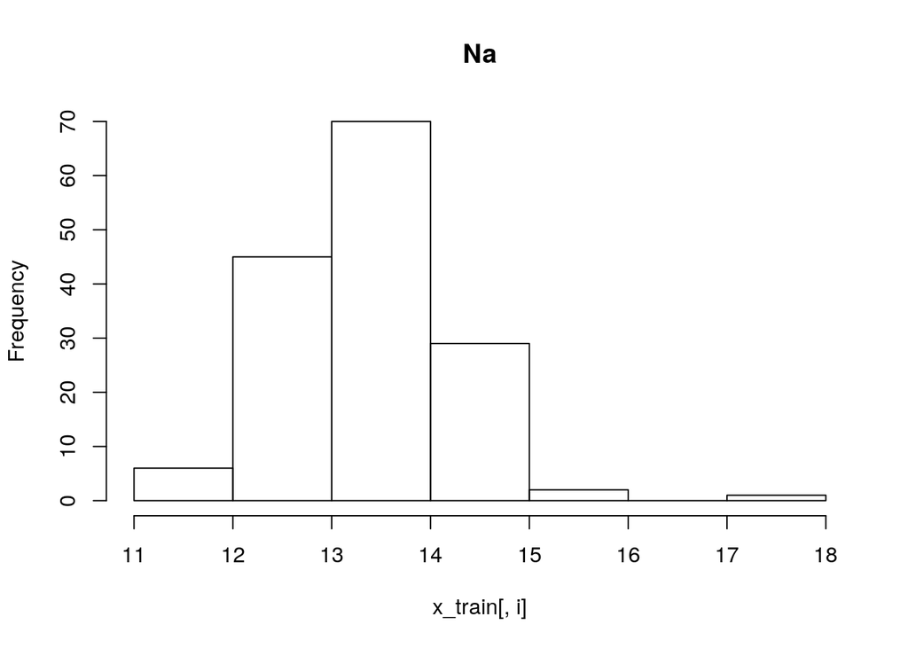

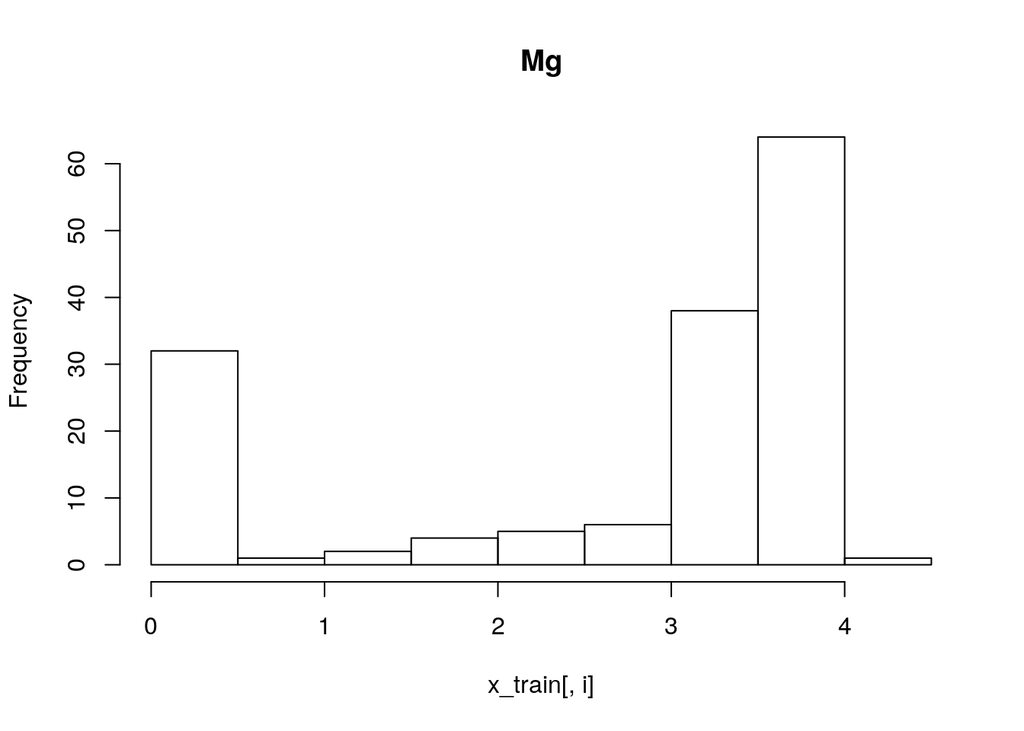

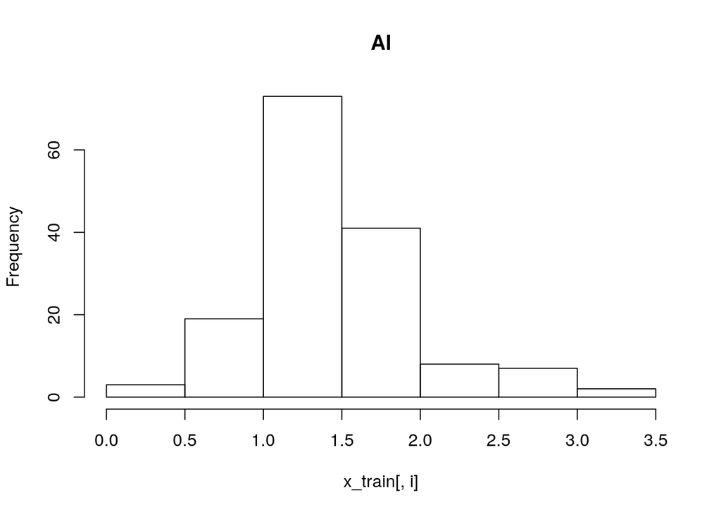

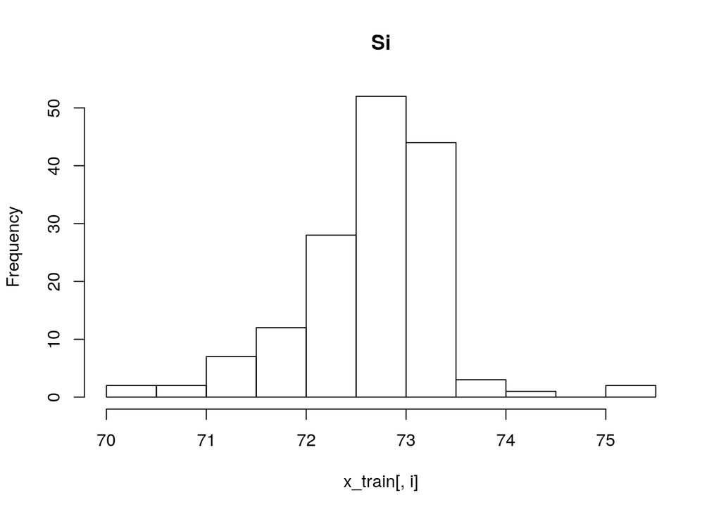

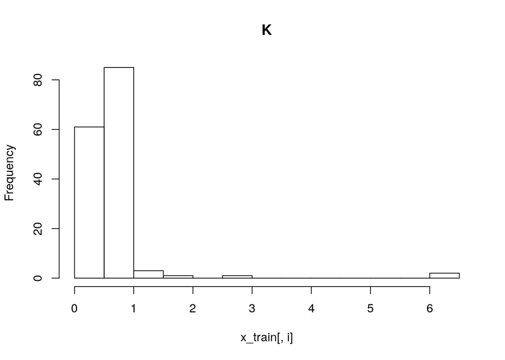

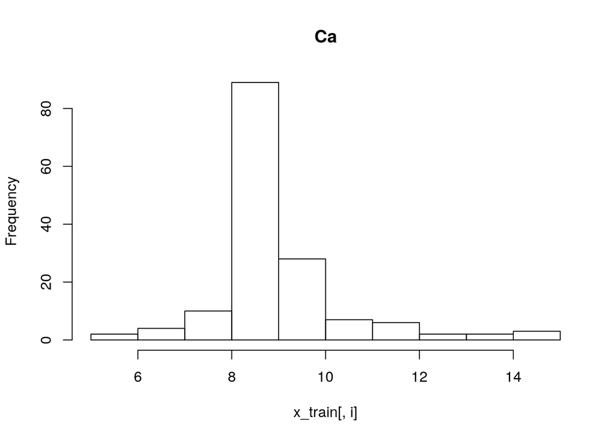

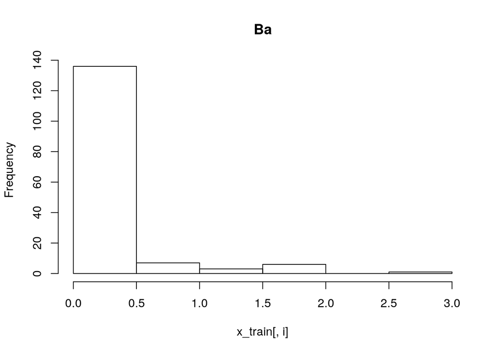

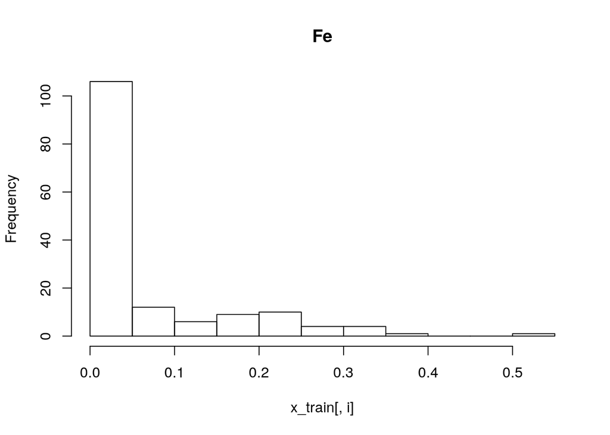

```r
# Histograms each attribute
# par(mfrow=c(dispRow,dispCol))
for(i in 1:totAttr) {
    hist(x_train[,i], main=names(x_train)[i])
}
```